# Midterm DS 2003

Declan Young, Devin Seay, Saif Karim

10/11/2022

### **Our chosen dataset examines over 200 students enrolled in a math course at a University in Portugal . Within our dataset is a number of social, gender, and class variables with information that provide insight into the lives of these students. By examining this dataset we can explore the relationship between factors such as alcohol consumption, gender, age, romantic relationships, activites, absences, and even what your environment/family is like in order to gauge how each of these environmental factors can affect performance in school. The key variables within our dataset are- the number of past class failures (failure), the student’s age (age), going out with friends (goout-on a scale of 1-5), in a romantic relationship (romantic), weekly study time (study time), internet access at home (internet), student’s sex (sex), and whether or not they wanted to pursue higher education (higher). While there were 33 variables examined in the study including those calculating the student’s grades throughout the semester, these eight variables were found to have the highest correlation to how well a student performed and are therefore our key variables.**

## **Question:** Does the level of weekend alcohol consumption in students relate to their final grades?

### **Hypothesis:** We believe that grades will decrease in students with higher weekend alcohol consumption levels.

```r
#Wrangling data to make a tibble with the average grade percent for each level of alcohol consumption
stud_alc_summarized <- stud_alc %>% mutate(G1 = (G1/20)*100) %>% group_by(as.factor(Walc)) %>% summarise(mean = round(mean(G1), 2), sd = sd(G1)) %>% rename('Weekend_Alcohol_Consumption' = 'as.factor(Walc)') %>% mutate(pct = '%') %>% unite(bar_label, c(mean, pct), sep = '', remove = FALSE)
stud_alc_summarized
```

```
## # A tibble: 5 × 5
##   Weekend_Alcohol_Consumption bar_label  mean    sd pct
##   <fct>                       <chr>     <dbl> <dbl> <chr>
## 1 1                           55.89%     55.9  17.5 %
## 2 2                           56.35%     56.4  16.5 %
## 3 3                           54.69%     54.7  16.3 %
## 4 4                           49.9%      49.9  13.9 %
## 5 5                           49.82%     49.8  15.8 %
```

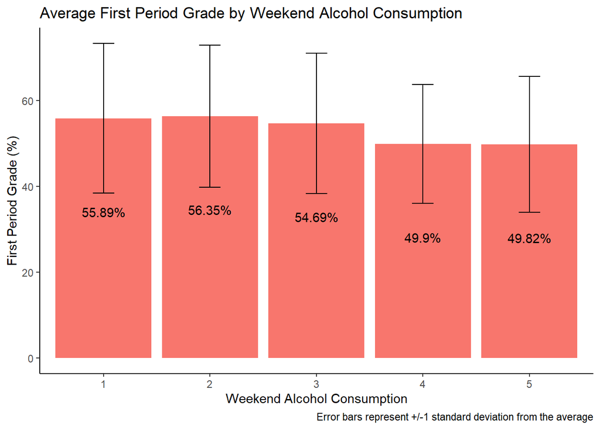

```r
#Creating the visualization using ggplot
ggplot(stud_alc_summarized, aes(x = Weekend_Alcohol_Consumption, y = mean, fill = 'pink')) + geom_bar(stat = 'identity', position = 'dodge') + theme_classic() + labs(title = "Average First Period Grade by Weekend Alcohol Consumption", caption = "Error bars represent +/-1 standard deviation from the average") + xlab("Weekend Alcohol Consumption") + ylab("First Period Grade (%)") +
  geom_errorbar(aes(ymin=mean-sd, ymax=mean+sd), width=.2,
                 position=position_dodge(.9)) + theme(legend.position = 'none') +geom_text(aes(label = bar_label), vjust = 10, colour = "black")
```

### **Findings:**

From the graph, we see that the grades of students worsen as alcohol consumption increases, especially as students cross a threshold from the 1-3 range to the 4-5 range. However, we cannot say that alcohol consumption causes grades to fall for two major reasons. First, a confounding variable could exist that causes both variables to vary with each other. For instance, perhaps course for older students have typically have lower grades across the class, and these students only drink more because they have better access to alcohol as legal students. Secondly, we would not be able to know which way the relationship between the two variables, so we cannot assume causality. It would be plausible for students who receive worse grades to turn to alcohol as a way to drown their sorrows away.

Additionally, although a five percent difference would be significant for many students (although, these students would average F’s using UVa’s grading scale), we cannot say there is a significant difference between these grades. We did not perform an statistical tests such as a ANOVA test to check whether the difference should be attributed to chance instead. Looking at the error bars (1 standard deviation from the averages in each direction or ~68% of the sample assuming normality), there are many students who seldom drink alcohol and still score below the average of those who drink alcohol heavily and many students who drink large amounts of alcohol and perform better in the classroom than the average of those students who drink small amounts.

Altogether, although we see a trend in the relationship between alcohol consumption and first period grade, it appears to follow more of a piece wise pattern than a linear or exponential pattern, and we cannot make any definitive conclusions.

## Question 2: What is the distribution of students’ weekend alcohol consumption by sex?

### **Hypothesis:** We believe that the number of students will taper off as the alcohol consumption level increases at similar proportions for both males and females.

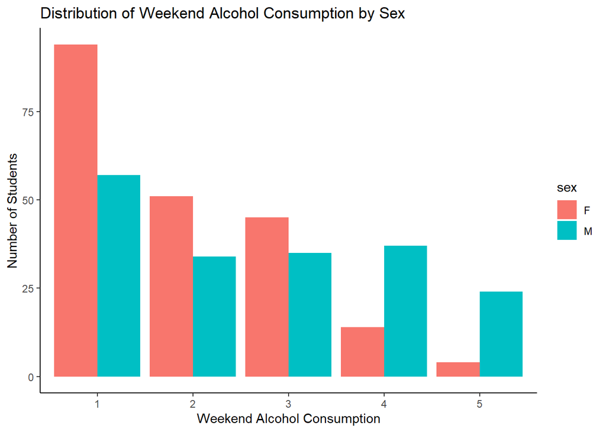

```r
stud_alc$Walc <- as.factor(stud_alc$Walc)
stud_alc$Dalc <- as.factor(stud_alc$Dalc)

ggplot(stud_alc, aes(x = Walc, fill = sex)) + geom_bar(position = 'dodge') + theme_classic() + labs(title = "Distribution of Weekend Alcohol Consumption by Sex") + xlab("Weekend Alcohol Consumption") + ylab("Number of Students")
```

### **Findings:**

As seen from the graph above, the amount of people in either sex tails off as the amount of alcohol consumption increases. Though, as we can also see from the grpah, the number of females who drink more tails off much more than the amount of males who drink more. While our hypothesis was correct in the sense that both sexes tail off as alcohol consumption increases, we were incorrect in predicting by how much: more males still consume more alcohol than females even at much higher alcohol consumptions levels.

All in all, while we do see a dipping trend in the number of people who consume levels of alcohol as the level of consumption increases, the rate at which the number of men falls falls much more slowly than that of women.